# Estimating infection incidence with augmented confirmed case counts

John Giles

## Outline

1. Correction of confirmed case counts

   A. Smoothing inferred incidence using basis splines

   B. Correcting over-reporting due to changed case definition in Hubei on Feb 13
2. Augment reported incidence to estimate infection incidence

   A. Simulate incubation period

   B. Fit and simulate delay from symptom onset to confirmation

   C. Adjust reported confirmation dates to account for delay in symptom onset and confirmation

# Smoothing and correction of confirmed case counts

This takes the dates of case confirmation and smoothes with splines to ensure monotonic increase then adjusts for the change in reporting in Hubei on Feb 13.

```r
#pull_JHUCSSE_github_data()

# Load in the JHU CSSE Data
jhucsse <- read_JHUCSSE_cases(Sys.time(), append_wiki=FALSE)
```

```
## [1] "data/JHUCSSE Total Cases 3-8-2020.csv"
## [1] "data/JHUCSSE Total Cases 3-7-2020.csv"
## [1] "data/JHUCSSE Total Cases 3-6-2020.csv"
## [1] "data/JHUCSSE Total Cases 3-5-2020.csv"
## [1] "data/JHUCSSE Total Cases 3-4-2020.csv"
## [1] "data/JHUCSSE Total Cases 3-3-2020.csv"
## [1] "data/JHUCSSE Total Cases 3-2-2020.csv"
## [1] "data/JHUCSSE Total Cases 3-1-2020.csv"
## [1] "data/JHUCSSE Total Cases 2-9-2020.csv"
## [1] "data/JHUCSSE Total Cases 2-8-2020.csv"
## [1] "data/JHUCSSE Total Cases 2-7-2020.csv"
## [1] "data/JHUCSSE Total Cases 2-6-2020.csv"
## [1] "data/JHUCSSE Total Cases 2-5-2020.csv"
## [1] "data/JHUCSSE Total Cases 2-4-2020.csv"
## [1] "data/JHUCSSE Total Cases 2-3-2020.csv"
```

[output cut: 32 more lines]

```r
jhucsse$Province_State <- as.factor(jhucsse$Province_State)

# Smoothing only
incidence_data <- est_daily_incidence(jhucsse,
                                      ISOdate(2019,12,1),
                                      Sys.time())

# Smoothing plus correct for the change in reportin on the 13th
corrected_hubei <- correct_for_Hubei_reporting(jhucsse,
                                               ISOdate(2019,12,1),
                                               Sys.time())
```

```
## # A tibble: 23 x 3
##    Province_State Date                Incidence
##    <fct>          <dttm>                  <dbl>
##  1 Hubei          2020-02-15 12:00:00      933.
##  2 Hubei          2020-02-16 12:00:00     1989.
##  3 Hubei          2020-02-17 12:00:00     1883.
##  4 Hubei          2020-02-18 12:00:00     1513.
##  5 Hubei          2020-02-19 12:00:00     1060.
##  6 Hubei          2020-02-20 12:00:00      700.
##  7 Hubei          2020-02-21 12:00:00      506.
##  8 Hubei          2020-02-22 12:00:00      439.
##  9 Hubei          2020-02-23 12:00:00      441.
## 10 Hubei          2020-02-24 12:00:00      461.
## # … with 13 more rows
## [1] -2411.276 -2411.276
## [1] 34.93482 34.93482
```

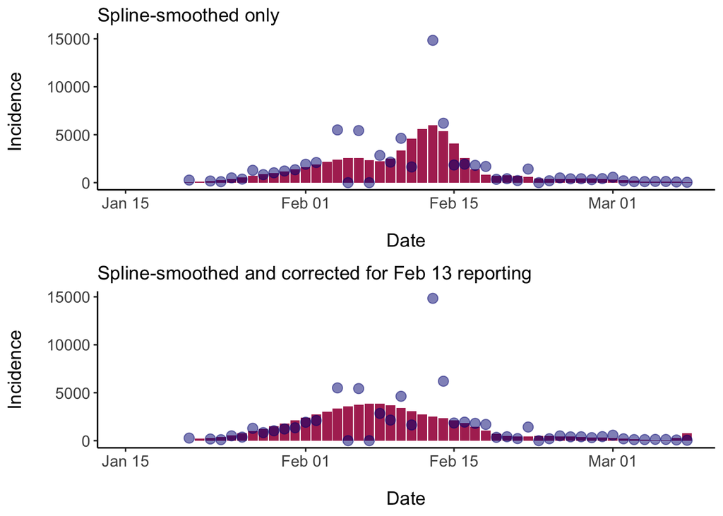

```r
gridExtra::grid.arrange(
  plot_incidence_ests_report_b(conf_cases=jhucsse, incid_ests=incidence_data, locations="Hubei") +
    ggtitle("Spline-smoothed only"),
  plot_incidence_ests_report_b(conf_cases=jhucsse, incid_ests=corrected_hubei, locations="Hubei") +
    ggtitle("Spline-smoothed and corrected for Feb 13 reporting"),
  nrow=2
)
```

```r
# Combine all incidence data with corrected Hubei and merge with cumulative confirmed counts
incidence_data$Incidence[incidence_data$Province_State == 'Hubei'] <- corrected_hubei$Incidence
head(incidence_data)
```

```
## # A tibble: 6 x 3
##   Province_State Date                Incidence
##   <fct>          <dttm>                  <dbl>
## 1 Hubei          2020-01-21 12:00:00        0
## 2 Hubei          2020-01-22 12:00:00      199.
## 3 Hubei          2020-01-23 12:00:00      266.
## 4 Hubei          2020-01-24 12:00:00      388.
## 5 Hubei          2020-01-25 12:00:00      555.
## 6 Hubei          2020-01-26 12:00:00      758.
```

# Estimate infection incidence using corrected case counts

Now that we have inferred the dates of confirmation for confirmed cases, we can simulate augmented data that will estimate the infection incidence. Infection incidence is estimated by adjusting corrected confirmation dates by the delay incurred from the incubation period and the time from symptom onset to case confirmation.

## Incubation period

To simulate the incubation period we used a log-normal distrubtion with parameters estimated by Lauer et al. ([2020](https://github.com/HopkinsIDD/ncov_incubation#data-summary)) who used exposure and symptom onset windows from cases outside Hubei that were within Mainland China and other countries. Simulated values of the incubation period $X$ are doubly stochastic allowing for uncertainty in the estimation of $\hat\mu$ and $\hat\sigma$. Both parameters are allowed to vary according to a normal distribution that is truncated by the 95% credible intervals of the posterior distributions.

$$X \sim \text{Log-normal}(\hat{\mu}, \hat{\sigma})$$

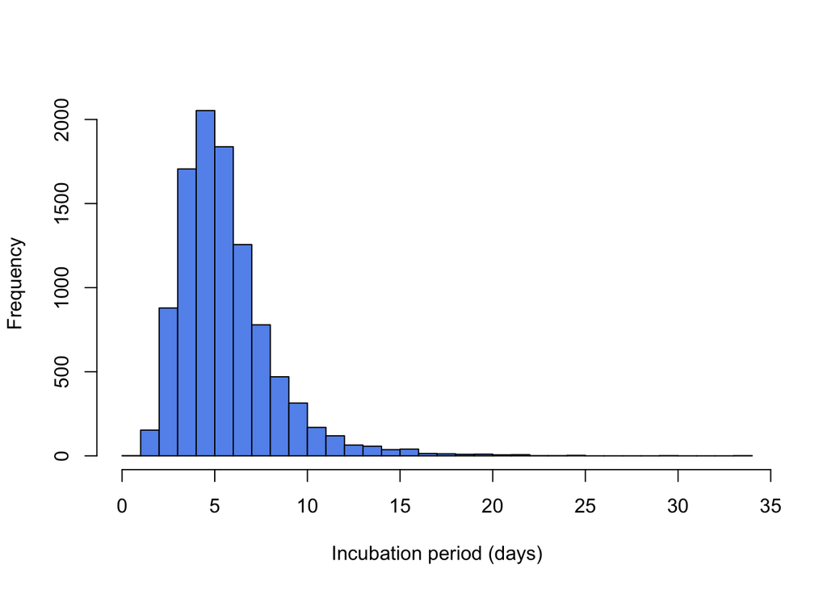

```r
hist(sim_inf_period(n=10000,
                    mu=1.621,
                    sigma=0.418,
                    mu_95low=1.504,
                    mu_95high=1.755,
                    sigma_95low=0.271,
                    sigma_95high=0.542,
                    n_obs=181),
     breaks=30,
     col='cornflowerblue',
     xlab='Incubation period (days)',
     main='')
```

## Confirmation delay

Based on preliminary models, it appears that there is more spatial variation in the time to confirmation among provinces than there is temporal variation in the population mean. Therefore, we estimated province-level time to confirmation using a Negative Binomial Bayesian model with hierarchical structure.

$$Y_j \sim \text{Negbin}(\hat{p}_j, \hat{r}_j)$$
Where, the random variable $y_j$ is the time in days from symptom onset to reported case confirmation in province $j$. Negative binomial parameters $p_j$ and $r_j$ are the success probability and dispersion parameter respectively. The model first estimates the population-level mean $p^\prime$ and $r^\prime$ which serve as hyper-priors to population-level parameters $p_j$ and $r_j$.
$$\begin{aligned}
p_j &\sim \text{Norm}(p^\prime, 0.01) \\
r_j &\sim \text{Norm}(r^\prime, 0.01)
\end{aligned}$$
Hyper-priors were defined as uninformative conjugate priors for the Negative Binomial distribution.

$$\begin{aligned}
p^\prime &\sim \text{Beta}(1,1) \\
r^\prime &\sim \text{Gamma}(0.01,0.01)
\end{aligned}$$

### Fitting time to confirmation model

We fit the model to public linelist data found in Moritz Kramer’s [googlesheets document](https://docs.google.com/spreadsheets/d/1itaohdPiAeniCXNlntNztZ_oRvjh0HsGuJXUJWET008/htmlview#).

```r
# Use saved data if too many requests on MK line list
#linelist_data <- read_MK_direct(save_csv=FALSE)
linelist_data <- read_csv('data/MK Line List 3-1-2020.csv')
linelist_data <- linelist_data[linelist_data$country == 'China',] # only looking at China
head(linelist_data)
```

```
## # A tibble: 6 x 12
##     age gender city  province country date_onset date_confirmati…
##   <dbl> <chr>  <chr> <chr>    <chr>   <date>     <date>
## 1    NA male   Wuha… Hubei    China   NA         2020-01-20
## 2    NA male   Wuha… Hubei    China   NA         2020-01-20
## 3    NA male   Wuha… Hubei    China   NA         2020-01-20
## 4    NA male   Wuha… Hubei    China   NA         2020-01-20
## 5    NA male   Wuha… Hubei    China   NA         2020-01-20
## 6    NA male   Wuha… Hubei    China   NA         2020-01-20
## # … with 5 more variables: date_admission <date>, admitted <dbl>,
## #   death <dbl>, time_to_care <dbl>, time_to_conf <dbl>
```

```r
mod <- fit_spatial_time_to_conf(data=linelist_data,
                                n_chains=3,
                                n_burn=1000,
                                n_samp=1000,
                                n_thin=1) # need to do more chains/samples for production run
```

```
## Calling 3 simulations using the parallel method...
## Following the progress of chain 1 (the program will wait for all
## chains to finish before continuing):
## Welcome to JAGS 4.3.0 on Mon Mar  9 22:05:57 2020
## JAGS is free software and comes with ABSOLUTELY NO WARRANTY
## Loading module: basemod: ok
## Loading module: bugs: ok
## . Loading module: lecuyer: ok
## . . Reading data file data.txt
## . Compiling model graph
## . Reading parameter file inits1.txt
## . Initializing model
## . Adapting 1000
## -------------------------------------------------| 1000
## ++++++++++++++++++++++++++++++++++++++++++++++++++ 100%
## Adaptation successful
## . Updating 1000
## -------------------------------------------------| 1000
## ************************************************** 100%
## . . . . . . . Updating 1000
## -------------------------------------------------| 1000
## ************************************************** 100%
## . . . . Updating 0
## . Deleting model
## .
## All chains have finished
## Simulation complete.  Reading coda files...
## Coda files loaded successfully
## Finished running the simulation
```

```r
time_to_conf_model <- summary(mod)
```

```
## Calculating summary statistics...
## Calculating the Gelman-Rubin statistic for 102 variables....
```

```r
head(time_to_conf_model)
```

```
##                Lower95    Median  Upper95      Mean         SD Mode
## p             0.394438 0.4226935 0.458600 0.4233140 0.01638763   NA
## r             4.192570 4.5801500 5.288400 4.5781307 0.28316381   NA
## mu            5.912700 6.2284950 6.601660 6.2296432 0.17289860   NA
## p_province[1] 0.408997 0.4487895 0.497701 0.4493193 0.02280903   NA
## p_province[2] 0.376426 0.4265185 0.479519 0.4271058 0.02637804   NA
## p_province[3] 0.267540 0.4287895 0.603667 0.4302459 0.08641816   NA
##                     MCerr MC%ofSD SSeff      AC.10     psrf
## p             0.002845529    17.4    33 0.63982832 1.767803
## r             0.080134196    28.3    12 0.91755715 1.992505
## mu            0.004179408     2.4  1711 0.01256704 1.000321
## p_province[1] 0.001595143     7.0   204 0.21197799 1.293006
## p_province[2] 0.001548256     5.9   290 0.18429784 1.288151
## p_province[3] 0.002122454     2.5  1658 0.01032893 1.018922
```

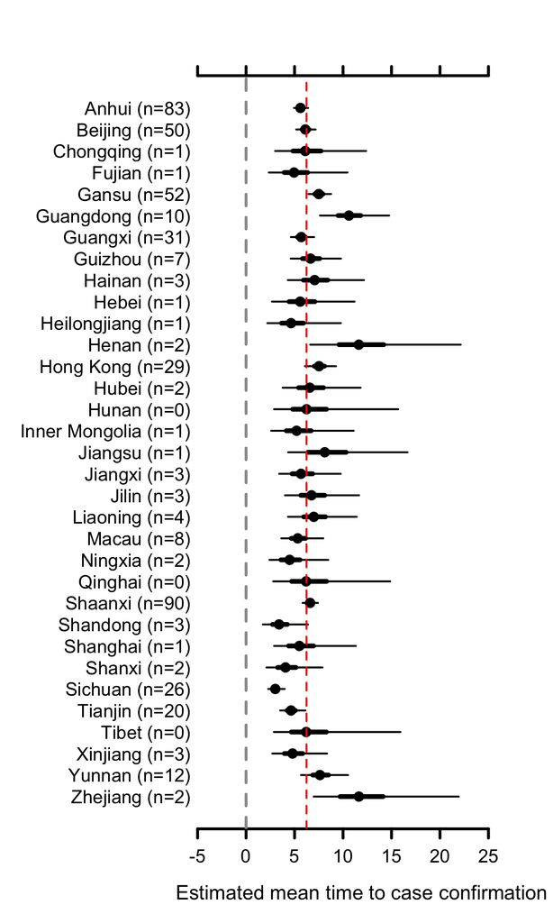

### Simulate time to confirmation for provinces

```r
# Simulate 5 replicates of time to confirmation for provinces 1 to 5
sim_spatial_time_to_conf(n=5, mod=time_to_conf_model, province=1:5)
```

```
##   province X1 X2 X3 X4 X5
## 1        1  1  3  5  5  3
## 2        2  4  9  5  8 20
## 3        3  3 14  8 20  5
## 4        4  2  1  2 14  5
## 5        5  2  7  9  5  6
```

# Data augmentation

Total delay from time of infection to time of confirmation is denoted as $\Delta t_{ij}$, which is the sum of the estimated incubation period $x_i$ for case $i$ and delay from symptom onset to case confirmation for each case $i$ in province $j$.

$$\Delta t_{ij} = x_i + y_{ij}$$
The estimated time of infection $t^{\text{infect}}_{ij}$ is estimated by taking the observed time of confirmation $t^{\text{confirm}}_{ij}$ and moving it back by $\Delta t_{ij}$:
$$t^{\text{infect}}_{ij} = t^{\text{confirm}}_{ij} - \Delta t_{ij}$$
Our quantity of interest is the augmented case count in province $j$ at time $t$. This is calculated as the sum of all $i$ cases in province $j$ for which estimated infection times are equal to $t$. Where $t \in T$ and $T$ is a vector of dates spanning the potential start of the outbreak to present $\{t_{\text{start}},\cdots, t_{\text{end}} \}$.
$$C_{jt} = \sum_i \mathbf{1}(t^{\text{infect}}_{ij} \mid t=t^{\text{infect}}_{ij})$$

### Simulate augmented infection times

Below is a function to simulate augmented infection times based on our models of both incubation period and time to confirmation. This function takes incidence data for one province and simulates $n$ scenarios of augmented infection times. Augmented infection times are gathered in a table and merged by date.

```r
province_names <- dimnames(Y_province)[[1]]

# Simulate 5 scenarios of infection times for the proivince Anhui
test <- sim_infection_times(n=10,
                            inc_data=incidence_data[incidence_data$Province_State == 'Anhui',],
                            time_to_conf_model=time_to_conf_model,
                            province_names=province_names,
                            n_cores=4)
```

```
## 4 cores registered for parallel backend
```

```
## Simulating 10 scenarios of infection time in Anhui...
```

```r
head(test, n=10)
```

```
##    province       date X1 X2 X3 X4 X5 X6 X7 X8 X9 X10
## 1     Anhui 2019-12-19 NA NA NA  1 NA NA NA NA NA  NA
## 2     Anhui 2019-12-25  1 NA NA NA NA NA NA NA NA  NA
## 3     Anhui 2019-12-27 NA NA NA NA NA NA NA  1 NA  NA
## 4     Anhui 2019-12-28 NA NA  1 NA NA NA  1 NA NA  NA
## 5     Anhui 2019-12-29 NA  1 NA NA  1  1 NA  1  1  NA
## 6     Anhui 2019-12-30  1 NA NA NA NA NA  1 NA NA  NA
## 7     Anhui 2019-12-31 NA  1  1 NA NA NA  2  2 NA   1
## 8     Anhui 2020-01-01 NA NA  1  2  1 NA  1 NA  1  NA
## 9     Anhui 2020-01-02 NA NA NA NA  4 NA NA  2 NA  NA
## 10    Anhui 2020-01-03 NA  1  2  1  1  1  2 NA  4   1
```

### Augmented infection incidence for all provinces

The function below gives the mean and 95% credible intervals for $C_{jt}$ defined above.

```r
linelist_data_china <- linelist_data %>% filter(country == 'China') # only looking at China

incidence_data_china <-
     incidence_data %>%
     #filter(Province_State %in% province_names) %>%
     filter(Province_State %in% province_names[1:3]) %>%
     mutate(Province_State=as.character(Province_State))

test <- augment_incidence(n=10,
                          incidence_data=incidence_data_china,
                          linelist_data=linelist_data_china,
                          time_to_conf_model=time_to_conf_model,
                          summarise=T,
                          n_cores=4)
```

```
## 4 cores registered for parallel backend
```

```
## Simulating 10 scenarios of infection time in Anhui...
```

```
## Simulating 10 scenarios of infection time in Beijing...
```

```
## Simulating 10 scenarios of infection time in Chongqing...
```

```r
head(test, n=10)
```

```
##    Province_State       Date     mean  lo95  hi95
## 1           Anhui 2019-12-24 1.000000 1.000 1.000
## 2           Anhui 2019-12-26 1.000000 1.000 1.000
## 3           Anhui 2019-12-27 1.000000 1.000 1.000
## 4           Anhui 2019-12-28 1.000000 1.000 1.000
## 5           Anhui 2019-12-29 1.000000 1.000 1.000
## 6           Anhui 2019-12-30 1.000000 1.000 1.000
## 7           Anhui 2019-12-31 1.250000 1.000 1.925
## 8           Anhui 2020-01-01 2.000000 1.000 3.000
## 9           Anhui 2020-01-02 1.285714 1.000 2.000
## 10          Anhui 2020-01-03 2.428571 1.165 5.400
```

### Merge with original data

Combine augmented infection indicence with inferred incidence and cumulative confirmed counts for easy plotting of all quantities.

```r
all_data <- merge_aug_data(cum_data=jhucsse,
                           inc_data=incidence_data_china,
                           aug_data=test)
head(all_data)
```

```
##   Province_State Country_Region Update Confirmed Deaths Recovered Latitude
## 1          Anhui Mainland China     NA        NA     NA        NA       NA
## 2          Anhui Mainland China     NA        NA     NA        NA       NA
## 3          Anhui Mainland China     NA        NA     NA        NA       NA
## 4          Anhui Mainland China     NA        NA     NA        NA       NA
## 5          Anhui Mainland China     NA        NA     NA        NA       NA
## 6          Anhui Mainland China     NA        NA     NA        NA       NA
##   Longitude Suspected       Date Incidence mean lo95 hi95
## 1  117.2264        NA 2019-12-24        NA    1    1    1
## 2  117.2264        NA 2019-12-26        NA    1    1    1
## 3  117.2264        NA 2019-12-27        NA    1    1    1
## 4  117.2264        NA 2019-12-28        NA    1    1    1
## 5  117.2264        NA 2019-12-29        NA    1    1    1
## 6  117.2264        NA 2019-12-30        NA    1    1    1
```